# 第29章 安定性と推定の局面（1）

/Users/kazuo/Dropbox/RStudio/CAiP3/CAiP3_chap29.Rmd

fujimoto@sakushin-u.ac.jp

2019/6/15

- Initial release “2019/6/15”
- このスクリプトは、CARME-N のCAiP2 のサンプルコード、chap25のものである。
- http://www.carme-n.org/?sec=code2
- CAiP3 ではこの内容は、chap29,30に展開されている。chap29「安定性と推定の局面」chap30「並び替え検定」（これらのサンプルコードとしてはまだ公開されていない）

```r
library(ca)
library(ellipse)
library(tidyverse)
```

# 1 CAiP3 第29章安定性と推定

- CAiP2 第25章 安定性と推定
- Chapter 25: Aspects of Stability and Inference

```r
# Assuming ca package installed load data set author
data(author)
```

# 2 データを眺める

```r
author
```

```
##                                a   b   c   d    e   f   g   h   i  j  k   l   m   n   o   p q   r
## three daughters (buck)       550 116 147 374 1015 131 131 493 442  2 52 302 159 534 516 115 4 409
## drifters (michener)          515 109 172 311  827 167 136 376 432  8 61 280 146 470 561 140 4 368
## lost world (clark)           590 112 181 265  940 137 119 419 514  6 46 335 176 403 505 147 8 395
## east wind (buck)             557 129 128 343  996 158 129 571 555  4 76 291 247 479 509  92 3 413
## farewell to arms (hemingway) 589  72 129 339  866 108 159 449 472  7 59 264 158 504 542  95 0 416
## sound and fury 7 (faulkner)  541 109 136 228  763 126 129 401 520  5 72 280 209 471 589  84 2 324
## sound and fury 6 (faulkner)  517  96 127 356  771 115 189 478 558  6 80 322 163 483 617  82 8 294
## profiles of future (clark)   592 151 251 238  985 168 152 381 544  7 39 416 236 526 524 107 9 418
## islands (hemingway)          576 120 136 404  873 122 156 593 406  3 90 281 142 516 488  91 3 339
## pendorric 3 (holt)           557  97 145 354  909  97 121 479 431 10 94 240 154 417 477 100 3 305
## asia (michener)              554 108 206 243  797 164 100 328 471  4 34 293 149 482 532 145 8 361
## pendorric 2 (holt)           541  93 149 390  887 133 154 463 518  4 65 265 194 484 545  70 4 299
##                                s   t   u   v   w  x   y  z
## three daughters (buck)       467 632 174  66 155  5 150  3
## drifters (michener)          387 632 195  60 156 14 137  5
## lost world (clark)           464 670 224 113 146 13 162 10
## east wind (buck)             533 632 181  68 187 10 184  4
## farewell to arms (hemingway) 314 691 197  64 225  1 155  2
## sound and fury 7 (faulkner)  454 672 247  71 160 11 280  1
## sound and fury 6 (faulkner)  358 685 225  37 216 12 171  5
## profiles of future (clark)   508 655 226  89 106 15 142 20
## islands (hemingway)          349 640 194  40 250  3 104  5
## pendorric 3 (holt)           415 597 237  64 194  9 140  4
## asia (michener)              402 630 196  66 149  2  80  6
## pendorric 2 (holt)           423 644 193  66 218  2 127  2
```

```r
author %>% .[1,] %T>% print %>% sum()
```

```
##    a    b    c    d    e    f    g    h    i    j    k    l    m    n    o    p    q    r    s
##  550  116  147  374 1015  131  131  493  442    2   52  302  159  534  516  115    4  409  467
##    t    u    v    w    x    y    z
##  632  174   66  155    5  150    3
```

```
## [1] 7144
```

## 2.1 ca で対応分析を行う

- 後ほど、このresに対して、サプリメントpointを投影する

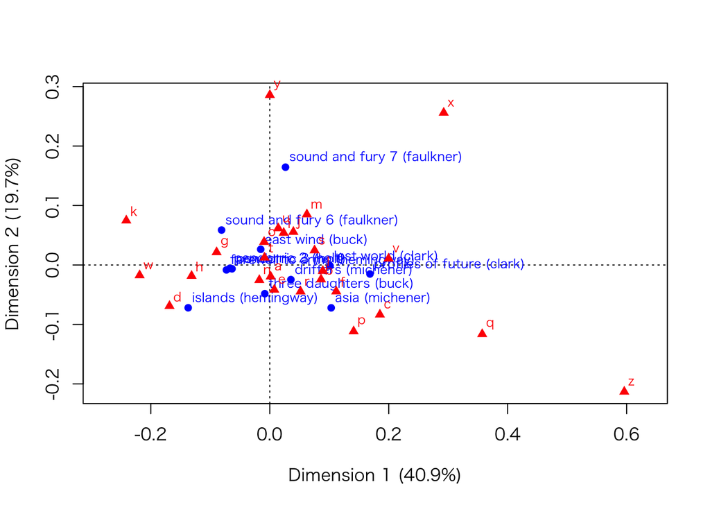

```r
author.ca <- ca(author)
plot(author.ca)
```

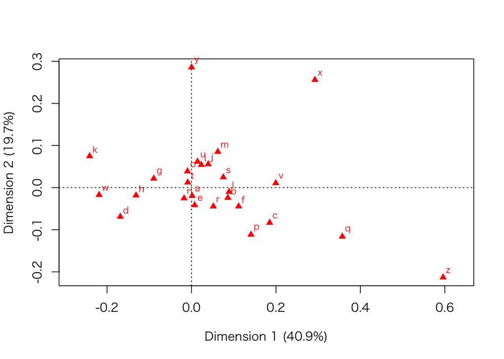

```r
plot(author.ca,what = c("none", "all"))
```

# 3 リサンプリングでcaするtableをnsim個生成する

## 3.1 rmultinorm の使い方

```r
set.seed(123)
A <- c(5,3,3,8) # このような分布があったとする。
sum(A) # これが周辺度数
```

```
## [1] 19
```

```r
#これをもとに多項分布の乱数を10 セット用意する。
res.muln <- rmultinom(10,sum(A),prob = A)
res.muln %>% addmargins(1)
```

```
##     [,1] [,2] [,3] [,4] [,5] [,6] [,7] [,8] [,9] [,10]
##        4    7    5    5    6    7    4    6    6     5
##        4    5    5    6    3    2    6    3    4     2
##        3    0    3    2    1    1    4    7    3     2
##        8    7    6    6    9    9    5    3    6    10
## Sum   19   19   19   19   19   19   19   19   19    19
```

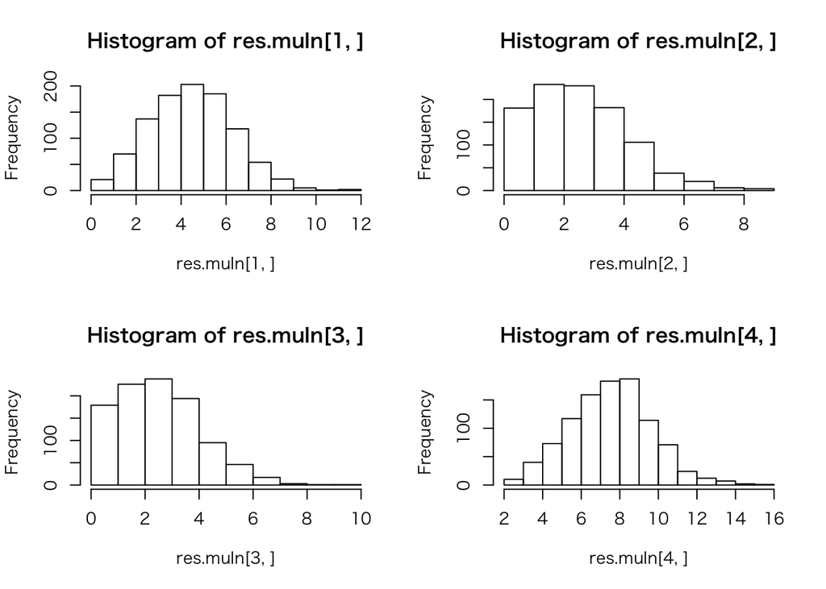

```r
res.muln <- rmultinom(1000,sum(A),prob = A)
oldpar <- par(mfrow=c(2,2))
hist(res.muln[1,])
hist(res.muln[2,])
hist(res.muln[3,])
hist(res.muln[4,])
```

```r
par(oldpar)
```

```r
#author.ca <- ca(author)
nsim      <- 100       # number of simulations
#nsim      <- 10       # number of simulations

# compute row sums
author.rowsum <- apply(author, 1, sum)
author.rowsum
```

```
##       three daughters (buck)          drifters (michener)           lost world (clark)
##                         7144                         6669                         7100
##             east wind (buck) farewell to arms (hemingway)  sound and fury 7 (faulkner)
##                         7479                         6877                         6885
##  sound and fury 6 (faulkner)   profiles of future (clark)          islands (hemingway)
##                         6971                         7505                         6924
##           pendorric 3 (holt)              asia (michener)           pendorric 2 (holt)
##                         6650                         6510                         6933
```

```r
# compute nsim simulations of first book:"three daughters (buck) "
author.rowsum[1]
```

```
## three daughters (buck)
##                   7144
```

```r
author[1,]
```

```
##    a    b    c    d    e    f    g    h    i    j    k    l    m    n    o    p    q    r    s
##  550  116  147  374 1015  131  131  493  442    2   52  302  159  534  516  115    4  409  467
##    t    u    v    w    x    y    z
##  632  174   66  155    5  150    3
```

```r
author.sim <- rmultinom(nsim, author.rowsum[1], prob = author[1,])
author.sim[1:6,1:17] # 第1行に対して、多項分布でリサンプリングした。
```

```
##   [,1] [,2] [,3] [,4] [,5] [,6] [,7] [,8] [,9] [,10] [,11] [,12] [,13] [,14] [,15] [,16] [,17]
## a  505  587  554  554  556  547  547  568  533   594   539   559   509   532   556   518   579
## b  125   97   90  110  114  116  109  121  131   108   104   118    95   127   132   126   122
## c  162  159  149  170  121  158  157  141  145   164   152   155   124   160   156   141   155
## d  362  373  383  354  367  360  406  418  377   372   392   368   381   387   363   392   370
## e 1064 1037  984  995 1060  999  995  982 1005  1054  1013  1026  1029  1014  1002   979  1025
## f  141  126  124  133  121  135  128  128  133   121   134   129   119   121   127   142   146
```

```r
           # rmultinom(n=100, size=author.rowsum[j], prob=author[j,]) # Appendix B のp281

# compute nsim simulations of other books and column-bind:他の本も生成する2:12
for (i in 2:12) {
   author.sim <- cbind(author.sim, rmultinom(nsim, author.rowsum[i],
                                             prob = author[i,]))
   }

# transpose to have same format as original matrix 元行列と合わせるために転置
author.sim  <- t(author.sim)
author.sim2 <- matrix(rep(0,12*nsim*26), nrow = 12*nsim)# author.sim2 として0行列

# reorganize rows so that matrices are together
for (k in 1:nsim) {
   for (i in 1:12) {
      author.sim2[(k-1)*12+i,] <- author.sim[k+(i-1)*nsim,]
      }
   }
## ここまででリサンプリングしたtableがnsim個できた。 -> author.sim2
author.sim2 %>% head()
```

```
##      [,1] [,2] [,3] [,4] [,5] [,6] [,7] [,8] [,9] [,10] [,11] [,12] [,13] [,14] [,15] [,16] [,17]
## [1,]  505  125  162  362 1064  141  125  486  437     2    45   302   172   574   486   105     6
## [2,]  521  103  167  343  815  180  144  362  417     8    47   280   154   487   536   135     1
## [3,]  614  114  192  262  955  164  126  419  490     2    41   340   142   380   472   154     6
## [4,]  585  111  122  348  912  167  114  583  539     4    64   294   254   506   467    96     2
## [5,]  587   78  123  358  868  122  179  452  410     5    60   270   168   511   534   103     0
## [6,]  511  109  128  231  763  129  140  414  522     5    60   320   221   495   573    82     0
##      [,18] [,19] [,20] [,21] [,22] [,23] [,24] [,25] [,26]
## [1,]   392   486   612   175    44   179     5   150     2
## [2,]   352   381   671   202    61   138    13   145     6
## [3,]   393   460   671   227   134   167    10   152    13
## [4,]   426   557   649   190    73   203    11   196     6
## [5,]   424   319   659   194    59   233     2   158     1
## [6,]   338   444   640   245    69   160     8   278     0
```

```r
#### このtableのプロファイルをサプリメントポイントとして、マップに投影する
# caのresultから行の標準座標を計算する。author,rowsc:get standard coordinates for rows
author.rowsc <- author.ca$rowcoord[,1:2]

# 転移公式をつかてって複製表の主座標を計算 calculate principal coordinates of all replicates using transition formula
author.colsim <- t(t(author.rowsc)%*%author.sim2[1:12,])/
                   apply(author.sim2[1:12,], 2, sum)
for (k in 2:nsim) author.colsim <- rbind(author.colsim,
       t(t(author.rowsc)%*%author.sim2[((k-1)*12+1):(k*12),])/
         apply(author.sim2[((k-1)*12+1):(k*12),], 2, sum))

# reorganize rows of coordinates so that letters are together
author.colsim2 <- matrix(rep(0,26*nsim*2), nrow = 26*nsim)
for (j in 1:26) {
   for (k in 1:nsim) {
      author.colsim2[(j-1)*nsim+k,] <- author.colsim[j+(k-1)*26,]
      }
   }
```

# 4 plot all points (use first format of coords for labelling…)

## 4.1 Exhibit 29.1

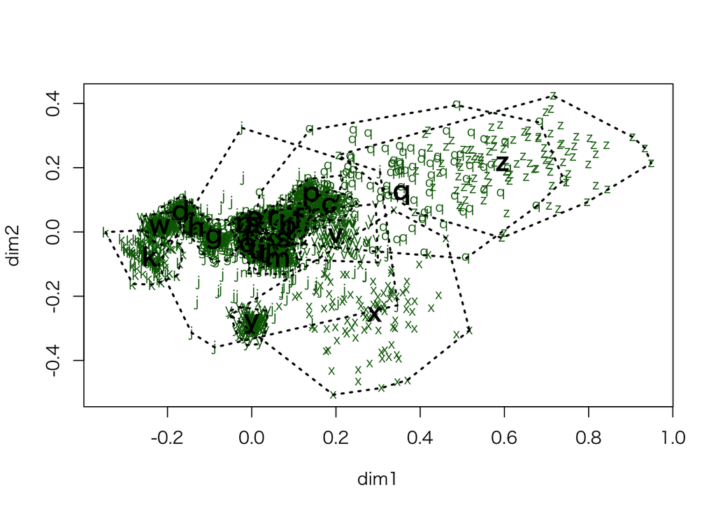

```r
# plot all points (use first format of coords for labelling...)
plot(author.colsim[,1], -author.colsim[,2], xlab = "dim1", ylab = "dim2",
     type = "n")
letters <- c("a","b","c","d","e","f","g","h","i","j","k","l","m","n","o",
             "p","q","r","s","t","u","v","w","x","y","z")
text(author.colsim[,1], -author.colsim[,2], letters, cex = 0.8, col="darkgreen")#col = "gray")

# plot convex hulls for each letter （各文字の凸包をplotする）
# first calculate principal coordinates of letters for original matrix
#　（元行列での文字の主座標を計算する。.rowsc:行標準座標）
author.col <- t(t(author.rowsc)%*%author)/apply(author, 2, sum)
for (j in 1:26) {
   points <- author.colsim2[(nsim*(j-1)+1):(nsim*j),]
  # note we are reversing second coordinate in all these plots
   points[,2] <- -points[,2]
   hpts       <- chull(points)
   hpts       <- c(hpts,hpts[1])
   lines(points[hpts,], lty = 3, lwd = 2)
   text(author.col[j,1], -author.col[j,2], letters[j], font = 2, cex = 1.5)
   }
```

## 4.2 Exhibit 29.2

- 以下のチャンクは、functionにして、nsimの値をあてると、resultでデータを取得できるようにすること。

```r
#author.ca <- ca(author)
nsim      <- 1000       # number of simulations
#nsim      <- 10       # number of simulations

# compute row sums
author.rowsum <- apply(author, 1, sum)
author.rowsum
```

```
##       three daughters (buck)          drifters (michener)           lost world (clark)
##                         7144                         6669                         7100
##             east wind (buck) farewell to arms (hemingway)  sound and fury 7 (faulkner)
##                         7479                         6877                         6885
##  sound and fury 6 (faulkner)   profiles of future (clark)          islands (hemingway)
##                         6971                         7505                         6924
##           pendorric 3 (holt)              asia (michener)           pendorric 2 (holt)
##                         6650                         6510                         6933
```

```r
# compute nsim simulations of first book:"three daughters (buck) "
author.rowsum[1]
```

```
## three daughters (buck)
##                   7144
```

```r
author[1,]
```

```
##    a    b    c    d    e    f    g    h    i    j    k    l    m    n    o    p    q    r    s
##  550  116  147  374 1015  131  131  493  442    2   52  302  159  534  516  115    4  409  467
##    t    u    v    w    x    y    z
##  632  174   66  155    5  150    3
```

```r
author.sim <- rmultinom(nsim, author.rowsum[1], prob = author[1,])
author.sim[1:6,1:17] # 第1行に対して、多項分布でリサンプリングした。
```

```
##   [,1] [,2] [,3] [,4] [,5] [,6] [,7] [,8] [,9] [,10] [,11] [,12] [,13] [,14] [,15] [,16] [,17]
## a  580  509  515  578  572  561  560  518  541   588   587   543   539   573   545   529   533
## b  112  102  113  106  131   94  100  125  114   108   113   124   101   121    99   127   117
## c  153  145  141  174  151  142  175  149  120   151   135   148   145   164   150   153   162
## d  362  385  421  360  390  408  381  369  380   378   395   354   388   351   378   402   341
## e  971 1056  991  995 1000 1015 1001 1023 1014  1025   951  1037  1014  1012   996   985  1028
## f  133  126  135  135  126  137  129  130  137   142   138   139   140   125   124   116   125
```

```r
           # rmultinom(n=100, size=author.rowsum[j], prob=author[j,]) # Appendix B のp281

# compute nsim simulations of other books and column-bind:他の本も生成する2:12
for (i in 2:12) {
   author.sim <- cbind(author.sim, rmultinom(nsim, author.rowsum[i],
                                             prob = author[i,]))
   }

# transpose to have same format as original matrix 元行列と合わせるために転置
author.sim  <- t(author.sim)
author.sim2 <- matrix(rep(0,12*nsim*26), nrow = 12*nsim)# author.sim2 として0行列

# reorganize rows so that matrices are together
for (k in 1:nsim) {
   for (i in 1:12) {
      author.sim2[(k-1)*12+i,] <- author.sim[k+(i-1)*nsim,]
      }
   }
## ここまででリサンプリングしたtableがnsim個できた。 -> author.sim2
author.sim2 %>% head()
```

```
##      [,1] [,2] [,3] [,4] [,5] [,6] [,7] [,8] [,9] [,10] [,11] [,12] [,13] [,14] [,15] [,16] [,17]
## [1,]  580  112  153  362  971  133  141  441  409     2    40   341   148   533   517   138     3
## [2,]  502  108  191  329  812  157  134  373  405     5    61   304   148   470   548   162     3
## [3,]  611  113  174  269  896  136  136  410  504     5    44   320   152   394   504   132    14
## [4,]  538  148  114  339 1022  154  129  521  562     3    69   301   227   507   562    83     2
## [5,]  557   67  140  340  851  119  157  464  472     4    67   273   167   513   532    97     0
## [6,]  545   88  128  229  771  139  138  402  551     5    66   290   206   446   603    82     2
##      [,18] [,19] [,20] [,21] [,22] [,23] [,24] [,25] [,26]
## [1,]   408   462   690   185    72   149     6   143     5
## [2,]   349   391   658   209    51   141    10   145     3
## [3,]   407   485   702   224   113   168    14   162    11
## [4,]   376   527   629   162    73   212    11   200     8
## [5,]   392   303   671   212    76   240     0   162     1
## [6,]   333   421   696   252    80   135     8   269     0
```

```r
#### このtableのプロファイルをサプリメントポイントとして、マップに投影する
# caのresultから行の標準座標を計算する。author,rowsc:get standard coordinates for rows
author.rowsc <- author.ca$rowcoord[,1:2]

# 転移公式をつかてって複製表の主座標を計算 calculate principal coordinates of all replicates using transition formula
author.colsim <- t(t(author.rowsc)%*%author.sim2[1:12,])/
                   apply(author.sim2[1:12,], 2, sum)
for (k in 2:nsim) author.colsim <- rbind(author.colsim,
       t(t(author.rowsc)%*%author.sim2[((k-1)*12+1):(k*12),])/
         apply(author.sim2[((k-1)*12+1):(k*12),], 2, sum))

# reorganize rows of coordinates so that letters are together
author.colsim2 <- matrix(rep(0,26*nsim*2), nrow = 26*nsim)
for (j in 1:26) {
   for (k in 1:nsim) {
      author.colsim2[(j-1)*nsim+k,] <- author.colsim[j+(k-1)*26,]
      }
   }
```

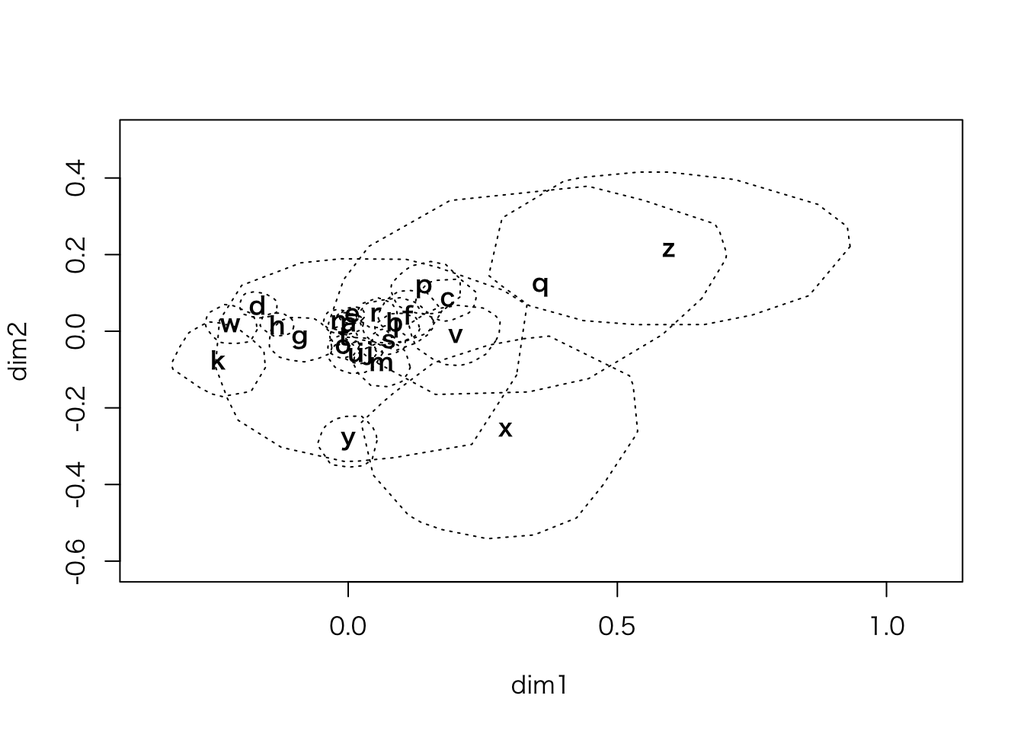

```r
# peeling a new convex hull (here we peel until just under 5% are removed)：新しい凸包を剥がす
plot(author.colsim2[,1], -author.colsim2[,2], xlab = "dim1", ylab = "dim2",
     type = "n")
for (j in 1:26) {
   points <- author.colsim2[(nsim*(j-1)+1):(nsim*j),]
   # note we are reversing second coordinate in all these plots
   points[,2] <- -points[,2]
   repeat {
     hpts <- chull(points)
     npts <- nrow(points[-hpts,])   #next number of points in peeled set
     if(npts/nsim < 0.95) break
     points <- points[-hpts,]
     }
   hpts <- c(hpts,hpts[1])
   lines(points[hpts,], lty = 3)
   text(author.col[j,1], -author.col[j,2], letters[j], font = 2)
   }
```

## 4.3 Exhibit 29.3

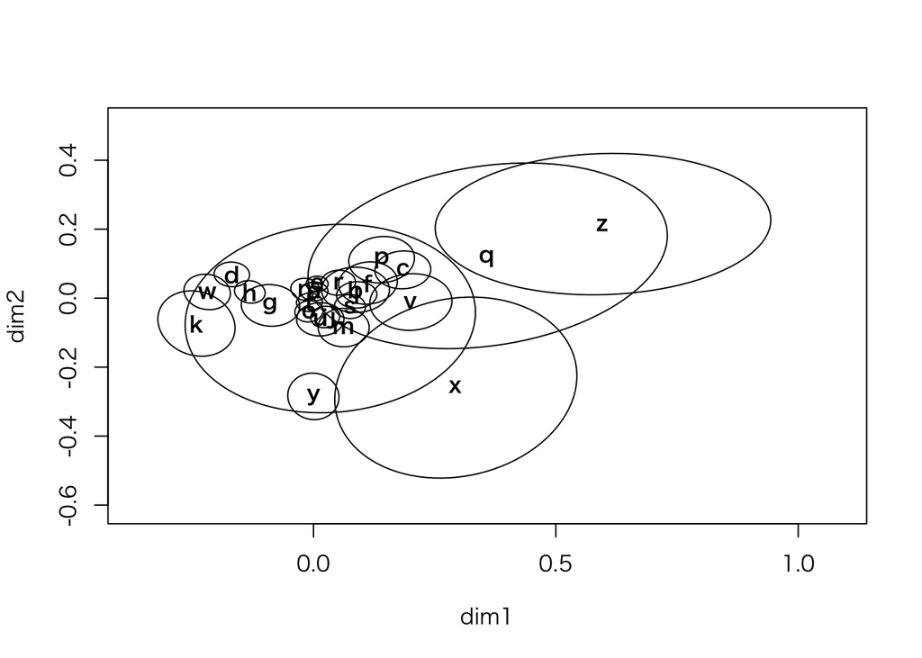

```r
# confidence ellipses - needs package ellipse (download from CRAN)
# （信頼楕円 ellipses package が必要）
plot(author.colsim2[,1], -author.colsim2[,2], xlab = "dim1", ylab = "dim2",
     type = "n")
for (j in 1:26) {
   points <- author.colsim2[(nsim*(j-1)+1):(nsim*j),]
   # note we are reversing second coordinate in all these plots
   points[,2] <- -points[,2]
   covpoints  <- cov(points)
   meanpoints <- apply(points,2,mean)
   lines(ellipse(covpoints, centre = meanpoints))
   text(author.col[j,1], -author.col[j,2], letters[j], font = 2)
   }
```

# 5 Delta method, using SPSS output contained in the file：SPSSの出力を用いたデルタメソッド

- ‘AUTHORDELTA.txt’. This is the file contents:以下の内容で’AUTHORDELTA.txt’を作ってある。

```
.007 .008  .000
.018 .025 -.043
.019 .024 -.275
.015 .016  .393
.009 .014 -.008
.021 .024 -.041
.019 .027 -.016
.012 .021  .066
.013 .013  .087
.077 .087  .023
.027 .033 -.173
.013 .016 -.004
.021 .028  .097
.011 .014  .043
.011 .020 -.004
.029 .035 -.080
.078 .094 -.001
.015 .017 -.065
.013 .024  .046
.006 .012 -.010
.016 .021  .029
.032 .040  .027
.015 .022  .073
.082 .087  .116
.039 .027 -.033
.091 .099 -.075
```

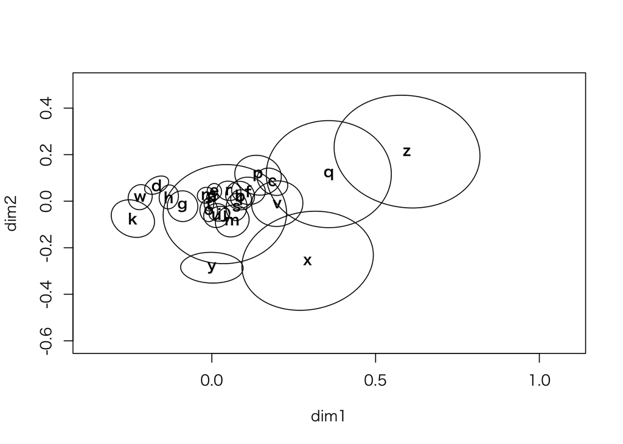

```r
# plot all points (use first format of coords for labelling...)
plot(author.colsim[,1], -author.colsim[,2], xlab = "dim1", ylab = "dim2",
     type = "n")
letters <- c("a","b","c","d","e","f","g","h","i","j","k","l","m","n","o",
             "p","q","r","s","t","u","v","w","x","y","z")

# calculate principal coordinates of column points（列ポイントに対する主座標を計算する。）
author.princol <- t(t(author.rowsc)%*%author)/apply(author, 2, sum)
text(author.princol[,1], -author.princol[,2], letters,font = 2)

# input covariances from SPSS output（SPSS出力から共分散を入力する）
covdelta <- read.table("AUTHORDELTA.txt")
for (j in 1:26) {
  covpoints[1,1] <- covdelta[j,1]^2
  covpoints[2,2] <- covdelta[j,2]^2
  covpoints[1,2] <- covdelta[j,3]*covdelta[j,1]*covdelta[j,2]
  covpoints[2,1] <- covpoints[1,2]
  lines(ellipse(covpoints, centre = c(author.princol[j,1],
                                      -author.princol[j,2])))
  }
```

# 6 FactoMineR でauthorをCAしてellipseCA で信頼楕円を描く

```r
library(FactoMineR)
library(factoextra)
library(ca)
```

```r
data(author)
res.CA <- CA(author,graph=FALSE)
summary(res.CA)
```

```
##
## Call:
## CA(X = author, graph = FALSE)
##
## The chi square of independence between the two variables is equal to 1567.112 (p-value =  1.57842e-179 ).
##
## Eigenvalues
##                        Dim.1   Dim.2   Dim.3   Dim.4   Dim.5   Dim.6   Dim.7   Dim.8   Dim.9
## Variance               0.008   0.004   0.002   0.001   0.001   0.001   0.001   0.000   0.000
## % of var.             40.907  19.687  12.870   7.381   5.347   3.861   3.515   2.428   1.996
## Cumulative % of var.  40.907  60.594  73.464  80.845  86.192  90.053  93.568  95.996  97.992
##                       Dim.10  Dim.11
## Variance               0.000   0.000
## % of var.              1.404   0.604
## Cumulative % of var.  99.396 100.000
##
## Rows (the 10 first)
##                                Iner*1000    Dim.1    ctr   cos2    Dim.2    ctr   cos2    Dim.3
## three daughters (buck)       |     0.817 | -0.008  0.078  0.007 | -0.048  5.398  0.244 | -0.051
## drifters (michener)          |     0.717 |  0.036  1.312  0.140 | -0.025  1.311  0.067 |  0.046
## lost world (clark)           |     1.400 |  0.101 11.378  0.623 | -0.001  0.005  0.000 | -0.017
## east wind (buck)             |     1.259 | -0.015  0.270  0.016 |  0.026  1.688  0.049 | -0.102
## farewell to arms (hemingway) |     1.242 | -0.073  5.690  0.351 | -0.008  0.153  0.005 |  0.046
## sound and fury 7 (faulkner)  |     2.461 |  0.026  0.751  0.023 |  0.164 60.342  0.904 |  0.009
## sound and fury 6 (faulkner)  |     1.679 | -0.081  7.139  0.326 |  0.059  7.792  0.171 |  0.071
## profiles of future (clark)   |     3.150 |  0.168 33.215  0.808 | -0.015  0.558  0.007 | -0.013
## islands (hemingway)          |     2.268 | -0.137 20.312  0.686 | -0.072 11.630  0.189 | -0.005
## pendorric 3 (holt)           |     1.018 | -0.063  4.176  0.314 | -0.006  0.090  0.003 | -0.034
##                                 ctr   cos2
## three daughters (buck)        9.035  0.267 |
## drifters (michener)           6.902  0.232 |
## lost world (clark)            1.070  0.018 |
## east wind (buck)             38.946  0.746 |
## farewell to arms (hemingway)  7.322  0.142 |
## sound and fury 7 (faulkner)   0.271  0.003 |
## sound and fury 6 (faulkner)  17.220  0.247 |
## profiles of future (clark)    0.643  0.005 |
## islands (hemingway)           0.091  0.001 |
## pendorric 3 (holt)            3.713  0.088 |
##
```

[output cut: 8 more lines]

```
## g                            |     0.491 | -0.089  2.086  0.325 |  0.021  0.250  0.019 |  0.071
## h                            |     1.555 | -0.131 14.634  0.721 | -0.018  0.594  0.014 | -0.067
## i                            |     0.522 |  0.023  0.501  0.074 |  0.054  5.546  0.392 |  0.017
## j                            |     0.134 |  0.040  0.016  0.009 |  0.056  0.066  0.018 |  0.113
##                                 ctr   cos2
## a                             0.584  0.075 |
## b                             2.071  0.145 |
## c                             2.916  0.062 |
## d                             0.396  0.006 |
## e                            12.804  0.485 |
## f                             0.290  0.013 |
## g                             4.231  0.208 |
## h                            12.197  0.189 |
## i                             0.869  0.040 |
## j                             0.415  0.075 |
```

```r
#str(res.CA)
```

## 6.1 plot.CA で描画

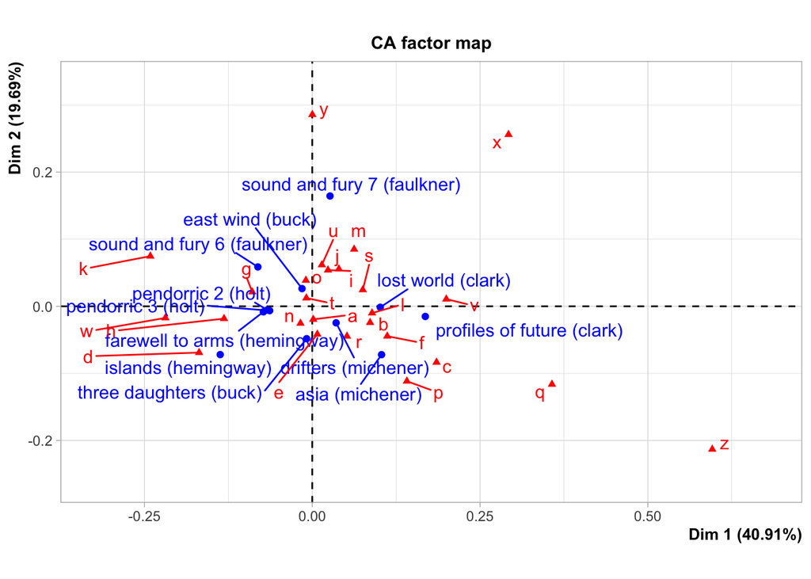

```r
plot(res.CA)
```

## 6.2 ellipseCA をmethod “boot”で実行

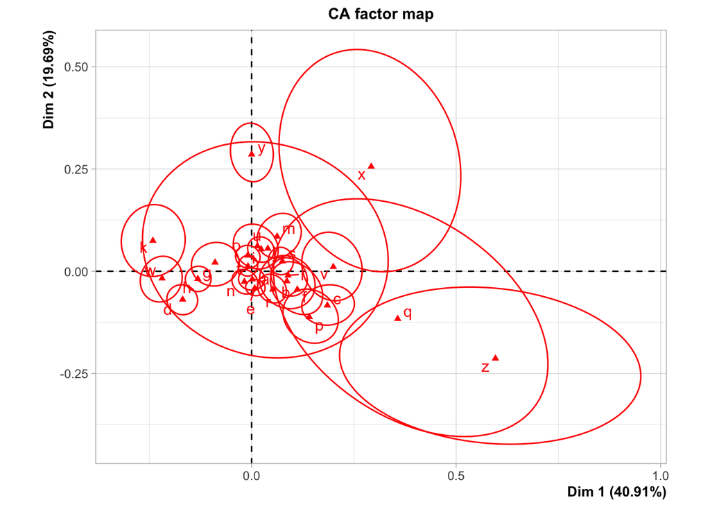

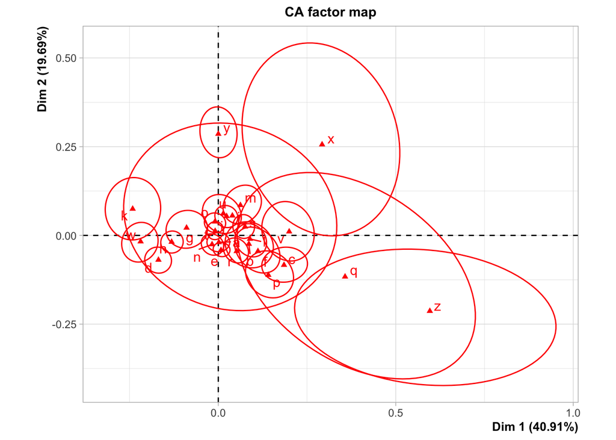

```r
ellipseCA(res.CA,ellipse = "col",invisible="row",method = "boot") + coord_fixed(ratio = 1)
```

## 6.3 ellipseCA をmethod “multinominal” で実行

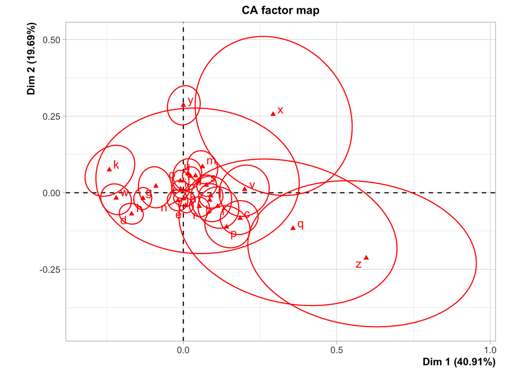

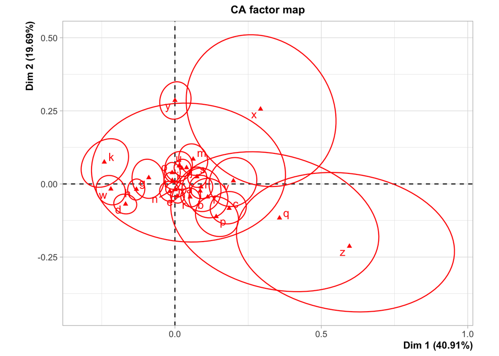

```r
ellipseCA(res.CA,ellipse = "col",invisible="row",method = "multinomial") + coord_fixed(ratio = 1)
```

## 6.4 fviz_ca で楕円も描画

- この楕円はなんだい？？

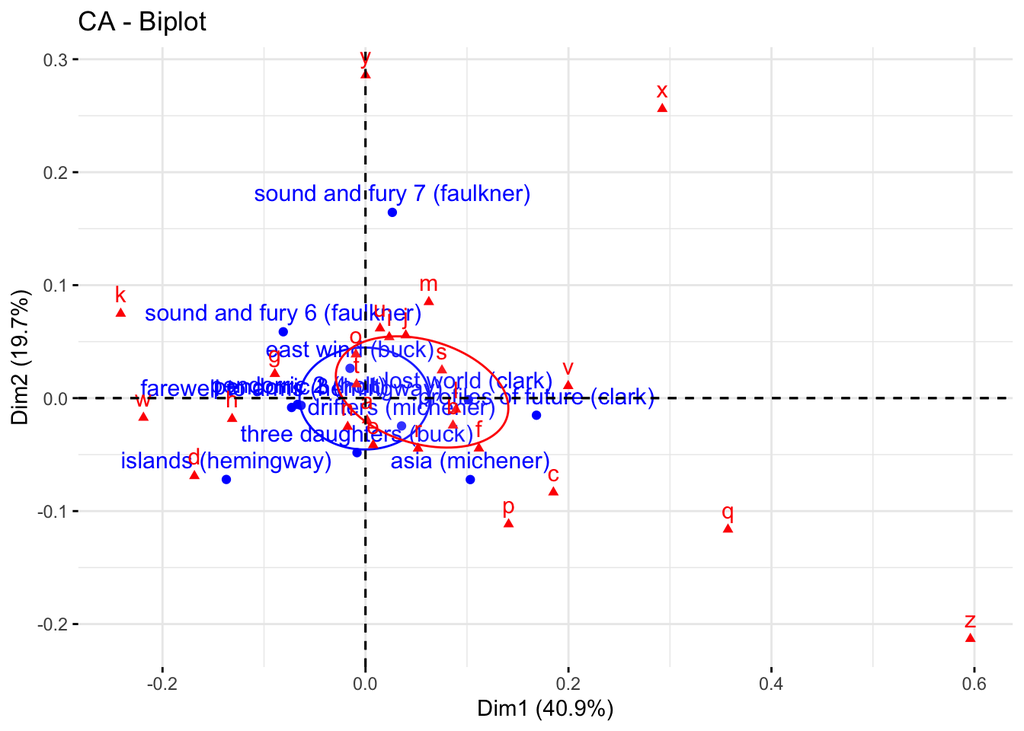

```r
fviz_ca(res.CA,addEllipses=TRUE,ellipse.type="confidence")
```

```r
#fviz_ellipses(res.CA,addEllipses=TRUE,ellipse.type="confidence")
```

# 7 未解決：Dim 2を逆転させたいが、これではダメ 楕円がついていかない…

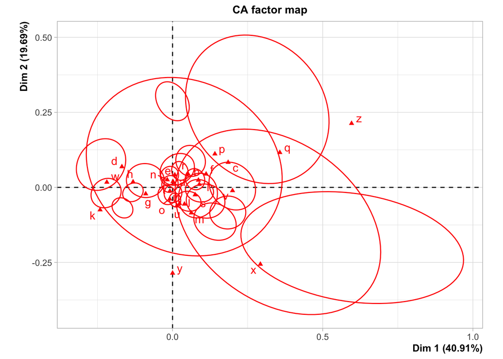

```r
#res.CA$row$coord[,2] <- -(res.CA$row$coord[,2])
res.CA$col$coord[,2] <- -(res.CA$col$coord[,2])
ellipseCA(res.CA,ellipse = "col",invisible="row",method = "multinomial")
```